# Practice on CNN

$\newcommand{\vect}[1]{\boldsymbol{#1}}$ $\newcommand{\transp}{^{\text{T}}}$ $\newcommand{\mat}[1]{\boldsymbol{\mathcal{#1}}}$ $\newcommand{\sign}{\text{sign}}$

In this practical we deal with a reduced version of the CIFAR10 dataset and train convolutional neural networks. We use a small subset of the dataset to be able to compute things in sensbile time within the tutorial.

The main focus is to see how “to assemble” different convolutional layers.

# CIFAR10

## Load the data

```r
library(keras)
```

```r
CIFAR10 <- dataset_cifar10()
```

```r
x_train <- CIFAR10$train$x/255
x_test  <- CIFAR10$test$x/255
y_train <- keras::to_categorical(CIFAR10$train$y, num_classes = 10)
y_test  <- keras::to_categorical(CIFAR10$test$y,  num_classes = 10)
label_name = c("flyer", "car", "bird", "cat", "deer", "dog", "frog ", "horse", "ship", "truck")
label_name
```

```
 [1] "flyer" "car"   "bird"  "cat"   "deer"  "dog"   "frog " "horse" "ship"  "truck"
```

```r
dim(x_train)
```

```
[1] 50000    32    32     3
```

```r
dim(x_test)
```

```
[1] 10000    32    32     3
```

```r
table(CIFAR10$train$y)
```

```
   0    1    2    3    4    5    6    7    8    9
5000 5000 5000 5000 5000 5000 5000 5000 5000 5000
```

We consider only 3 classes - not all 10

We use only “airplane”, “cat” and “truck” to make the problem “easier and quicker” for the practical

## Filter “airplane”, “cat” and “truck”

```r
ind.select.train <- which(CIFAR10$train$y==0|CIFAR10$train$y==3|CIFAR10$train$y==9)
ind.select.test <- which(CIFAR10$test$y==0|CIFAR10$test$y==3|CIFAR10$test$y==9)
length(ind.select.train)
```

```
[1] 15000
```

```r
length(ind.select.test)
```

```
[1] 3000
```

```r
x_train.filter <- x_train[ind.select.train,,,]
x_test.filter <- x_test[ind.select.test,,,]
y_train.filter <- CIFAR10$train$y[ind.select.train,]
y_test.filter <- CIFAR10$test$y[ind.select.test,]
y_train.filter.cat <- y_train[ind.select.train,c(1,4,10)]
y_test.filter.cat  <-  y_test[ind.select.test,c(1,4,10)]
```

Here I have chosen 8000 for train and 4000 validation but I have a “good” laptop. You migh try with a smaller data size such 2000 for the train set and 1000 for the validation set.

```r
trainLength <- 8000
validateLength <- 4000
trainRange <- 1:trainLength
validateRange <- (trainLength+1):(trainLength+validateLength)

x_train.filter.small <- x_train.filter[1:trainLength,,,]
y_train.filter.small <- y_train.filter.cat[1:trainLength,]
x_val.filter.small <- x_train.filter[(trainLength+1):(trainLength+validateLength),,,]
y_val.filter.small <- y_train.filter.cat[(trainLength+1):(trainLength+validateLength),]
```

## A first CNN using Keras

```r
img_width <- 32
img_height <- 32

model <- keras_model_sequential()

model %>%
    layer_conv_2d(filter = 8, kernel_size = c(3,3), strides=c(1,1),padding="same", activation="relu",
    input_shape = c(img_height, img_width, 3)) %>%
    layer_batch_normalization() %>%
    layer_max_pooling_2d(pool_size = c(2,2)) %>%
    layer_conv_2d(filter = 4, kernel_size = c(3,3), strides=c(1,1),padding="valid", activation="relu") %>%
    layer_batch_normalization() %>%
    layer_max_pooling_2d(pool_size = c(2,2)) %>%
    layer_flatten() %>%
    layer_dense(units = 80, activation = "relu")   %>%
    layer_dropout(rate = 0.5) %>%
    layer_dense(units = 40, activation = "relu")  %>%
    layer_dropout(rate = 0.5) %>%
    layer_dense(units = 3, activation = "softmax")

summary(model)
```

```
Model: "sequential_6"
___________________________________________________________________________________
Layer (type)                         Output Shape                     Param #
===================================================================================
conv2d_5 (Conv2D)                    (None, 32, 32, 8)                224
___________________________________________________________________________________
batch_normalization_5 (BatchNormaliz (None, 32, 32, 8)                32
___________________________________________________________________________________
max_pooling2d_4 (MaxPooling2D)       (None, 16, 16, 8)                0
___________________________________________________________________________________
conv2d_4 (Conv2D)                    (None, 14, 14, 4)                292
___________________________________________________________________________________
batch_normalization_4 (BatchNormaliz (None, 14, 14, 4)                16
___________________________________________________________________________________
max_pooling2d_3 (MaxPooling2D)       (None, 7, 7, 4)                  0
___________________________________________________________________________________
flatten_3 (Flatten)                  (None, 196)                      0
___________________________________________________________________________________
dense_13 (Dense)                     (None, 80)                       15760
___________________________________________________________________________________
dropout_5 (Dropout)                  (None, 80)                       0
___________________________________________________________________________________
dense_12 (Dense)                     (None, 40)                       3240
___________________________________________________________________________________
dropout_4 (Dropout)                  (None, 40)                       0
___________________________________________________________________________________
dense_11 (Dense)                     (None, 3)                        123
===================================================================================
Total params: 19,687
Trainable params: 19,663
Non-trainable params: 24
___________________________________________________________________________________
```

### TASK 0 : Try to understand the dimension of the layers and the number of parameters involved

## Visualize this model

```r
devtools::install_github("andrie/deepviz")
```

```r
library(deepviz)
model %>% plot_model()
```

[interactive chart not shown]

## Task 1:

- Modify the model to have $(5\times 5$) convolutions in the first layer and no max pooling layer after the second convolutional layer. No padding for the convolutional layers
- You’ll need to update the number of neurons in the dense layers.
- Call this model, model2.

```r
model2 <- keras_model_sequential()

model2 %>%
    layer_conv_2d(filter = 8, kernel_size = c(5,5), padding="valid",strides=c(1,1), activation="relu",
                  kernel_initializer = 'he_uniform',input_shape = c(img_height, img_width, 3)) %>%
    layer_batch_normalization() %>%
    layer_max_pooling_2d(pool_size = c(2,2)) %>%
    layer_conv_2d(filter = 4, kernel_size = c(3,3), strides=c(1,1),padding="valid",
                   kernel_initializer = 'he_uniform',activation="relu") %>%
    layer_batch_normalization() %>%
    layer_flatten() %>%
    layer_dense(units = 80, activation = "relu",kernel_initializer = 'he_uniform')   %>%
    layer_dropout(rate = 0.5) %>%
    layer_dense(units = 40, activation = "relu",kernel_initializer = 'he_uniform')  %>%
    layer_dropout(rate = 0.5) %>%
    layer_dense(units = 3, activation = "softmax",kernel_initializer = 'he_uniform')

summary(model2)
```

```
Model: "sequential_7"
___________________________________________________________________________________
Layer (type)                         Output Shape                     Param #
===================================================================================
conv2d_7 (Conv2D)                    (None, 28, 28, 8)                608
___________________________________________________________________________________
batch_normalization_7 (BatchNormaliz (None, 28, 28, 8)                32
___________________________________________________________________________________
max_pooling2d_5 (MaxPooling2D)       (None, 14, 14, 8)                0
___________________________________________________________________________________
conv2d_6 (Conv2D)                    (None, 12, 12, 4)                292
___________________________________________________________________________________
batch_normalization_6 (BatchNormaliz (None, 12, 12, 4)                16
___________________________________________________________________________________
flatten_4 (Flatten)                  (None, 576)                      0
___________________________________________________________________________________
dense_16 (Dense)                     (None, 80)                       46160
___________________________________________________________________________________
dropout_7 (Dropout)                  (None, 80)                       0
___________________________________________________________________________________
dense_15 (Dense)                     (None, 40)                       3240
___________________________________________________________________________________
dropout_6 (Dropout)                  (None, 40)                       0
___________________________________________________________________________________
dense_14 (Dense)                     (None, 3)                        123
===================================================================================
Total params: 50,471
Trainable params: 50,447
Non-trainable params: 24
___________________________________________________________________________________
```

## Training your model

- first set up the compiler

```r
model2 %>% compile(
  loss = 'categorical_crossentropy',
  metrics = 'accuracy',
  optimizer = optimizer_adam(learning_rate = 0.001)
)
```

- Fit the model

```r
epochs <- 20
batch.size <- 50

start.time <-  Sys.time()

history.model2 <- model2 %>% fit(
  x=x_train.filter.small, y=y_train.filter.small, validation_data = list(x_val.filter.small,y_val.filter.small),
  epochs = epochs, batch_size = batch.size, verbose=FALSE
)
end.time <- Sys.time()
(running.time <- end.time - start.time)
```

```
Time difference of 48.99664 secs
```

## Visualise the model 2

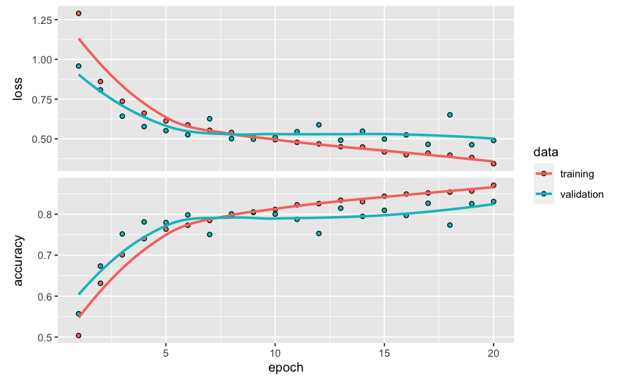

```r
plot(history.model2 )
```

## Evaluate Your Model

```r
model.acc <- model2 %>% tensorflow::evaluate(x_test.filter,y_test.filter.cat)
```

- Confusion matrix

```r
class.name <- c("airplane","cat","truck")
#pred<- model2 %>% keras::predict_classes(x_test.filter)
pred<- model2 %>% predict(x_test.filter) %>% k_argmax()
pred.class <- factor(as.vector(pred),labels=class.name)
true.class <- factor(y_test.filter,labels=class.name)
table(pred.class,true.class)
```

```
          true.class
pred.class airplane cat truck
  airplane      750  49    86
  cat           114 878    74
  truck         136  73   840
```

```r
(ACC <- sum(diag(table(pred.class,true.class)))/3000)
```

```
[1] 0.8226667
```

## Task 2

```r
model3 <- keras_model_sequential()

model3 %>%
    layer_conv_2d(filter = 10, kernel_size = c(5,5), ,padding="valid",strides=c(1,1), activation="relu",
                  kernel_initializer = 'he_uniform',input_shape = c(img_height, img_width, 3)) %>%
    layer_batch_normalization() %>%
    layer_max_pooling_2d(pool_size = c(2,2)) %>%
    layer_conv_2d(filter = 6, kernel_size = c(3,3), strides=c(1,1),padding="valid",
                   kernel_initializer = 'he_uniform',activation="relu") %>%
    layer_batch_normalization() %>%
    layer_max_pooling_2d(pool_size = c(2,2)) %>%
    layer_conv_2d(filter = 6, kernel_size = c(3,3), strides=c(1,1),padding="valid",
                   kernel_initializer = 'he_uniform',activation="relu") %>%
    layer_batch_normalization() %>%
    layer_flatten() %>%
    layer_dense(units = 120, activation = "relu",kernel_initializer = 'he_uniform')   %>%
    layer_dropout(rate = 0.5) %>%
    layer_dense(units = 60, activation = "relu",kernel_initializer = 'he_uniform')  %>%
    layer_dropout(rate = 0.5) %>%
    layer_dense(units = 3, activation = "softmax",kernel_initializer = 'he_uniform')

#summary(model3)
```

```r
model3 %>% compile(
  loss = 'categorical_crossentropy',
  metrics = 'accuracy',
  optimizer = optimizer_adam(learning_rate = 0.001)
)
```

```r
epochs <- 40
batch.size <- 50

start.time <-  Sys.time()

history.model3 <- model3 %>% fit(
  x=x_train.filter.small, y=y_train.filter.small, validation_data = list(x_val.filter.small,y_val.filter.small),
  epochs = epochs, batch_size = batch.size, verbose=FALSE
)
end.time <- Sys.time()

(running.time <- end.time - start.time)
```

```
Time difference of 2.102961 mins
```

## Visualise my new model

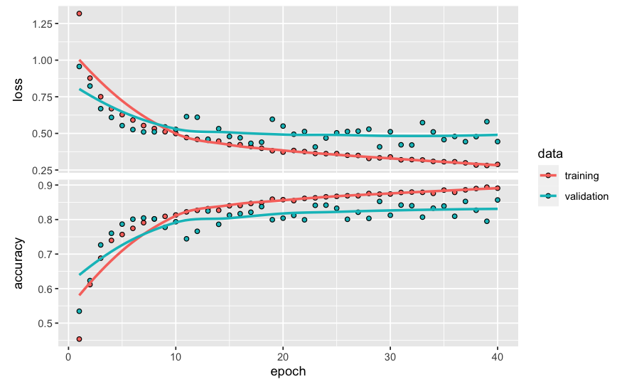

```r
plot(history.model3 )
```

## Evaluate my new model

```r
(model.acc <- model3 %>% tensorflow::evaluate(x_test.filter,y_test.filter.cat))
```

```
     loss  accuracy
0.4122629 0.8520000
```

- Confusion matrix

```r
class.name <- c("airplane","cat","truck")
pred<- model3 %>% predict(x_test.filter) %>% k_argmax()
pred.class <- factor(as.vector(pred),labels=class.name)
true.class <- factor(y_test.filter,labels=class.name)
table(pred.class,true.class)
```

```
          true.class
pred.class airplane cat truck
  airplane      791  48    45
  cat           107 875    65
  truck         102  77   890
```

```r
(ACC <- sum(diag(table(pred.class,true.class)))/3000)
```

```
[1] 0.852
```